# Working with sf objects

# Goals:

1. In the first exercise, you will learn to construct maps with `tmap()` by modifying the provided code. The libraries, data, and initial code is provided below.
2. In the second exercise, you learn to:
- Understand the provided datasets
- Learn how to reproject spatial data
- Limit your data into an area of interest
- Create a new map
3. In the third exercise, you reproject layers to a shared SRS.
4. In the fourth (and optional) exercise, you create a map of Denmark using online data.

#### Required R libraries

We will use the `sf`, `raster`, and `tmap` packages. Additionally, we will use the `spData` and `spDataLarge` packages that provide new datasets. To install the `spDataLarge`, please load it directly from the author’s github repository at https://github.com/Nowosad/spDataLarge. If the line in the chunk below does not work, check the repository for the other options.

```r
library(sf)
library(raster)
library(tmap)
library(spData)

# To install the spDataLarge uncomment the next line

# install.packages('spDataLarge', repos = 'https://geocompr.r-universe.dev')
# install.packages('spData')
library(spDataLarge)
```

# Exercise 1 - Make a map

In this exercise you will learn to make a map with `tmap` library, by adding spatial data layers and modifying the arguments that specify their rendering

#### Data sets

We will use two data sets: `nz_elev` and `nz`. They are contained by the libraries The first one is an elevation raster object for the New Zealand area, and the second one is an sf object with polygons representing the 16 regions of New Zealand.

#### Existing code

Here is the code to create a new map of New Zealand (following Robin Lovelace’s example). Your role is to improve this map based on the suggestions below.

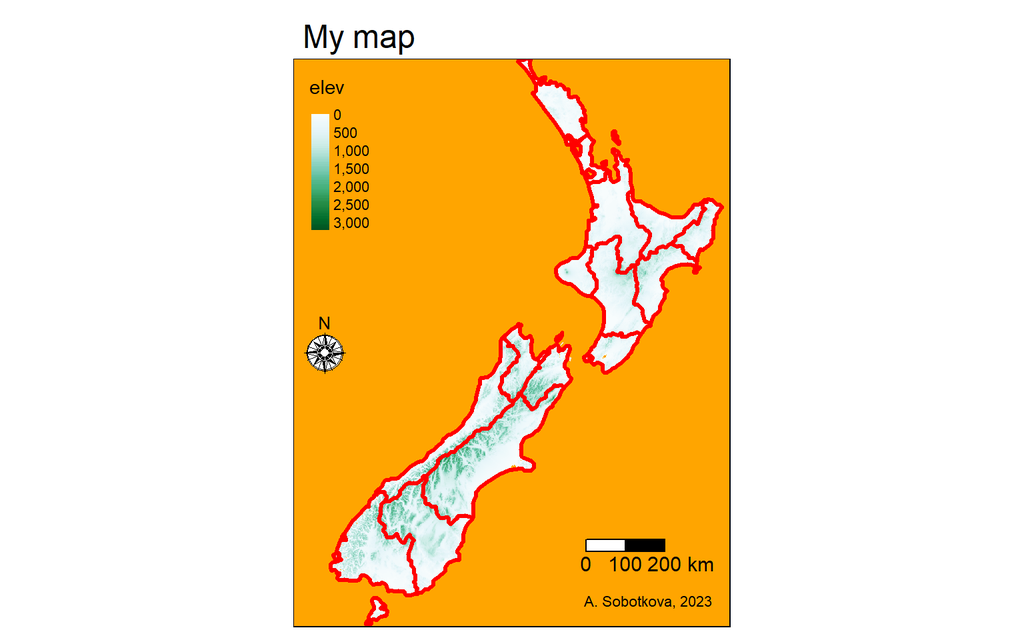

```r
tm_shape(nz_elev) + tm_raster(title = "elev", style = "cont", palette = "BuGn") +
    tm_shape(nz) + tm_borders(col = "red", lwd = 3) + tm_scale_bar(breaks = c(0,
    100, 200), text.size = 1) + tm_compass(position = c("LEFT", "center"), type = "rose",
    size = 2) + tm_credits(text = "A. Sobotkova, 2023") + tm_layout(main.title = "My map",
    bg.color = "orange", inner.margins = c(0, 0, 0, 0))
```

## Tasks

1. Change the map title from “My map” to “New Zealand”.
2. Update the map credits with your own name and today’s date.
3. Change the color palette to “-RdYlGn”. (You can also try other palettes from http://colorbrewer2.org/)
4. Put the north arrow in the top right corner of the map.
5. Improve the legend title by adding the used units (m asl).
6. Increase the number of breaks in the scale bar.
7. Change the borders’ color of the New Zealand’s regions to black. Decrease the line width.
8. Change the background color to any color of your choice.

## Your solution

```r
# /Start Code/

# /End Code/
```

# Exercise 2 - Inspect and display spatial data

We will use two data sets: `srtm` and `zion` , explore them and make a map. The first one is an elevation raster object for the Zion National Park area in Israel, and the second one is an sf object with polygons representing borders of the Zion National Park.

Read two new datasets, `srtm` and `zion`, using the code below and then follow the instructions and answer the questions related.

#### Preparation: Load data from provided package

You need to have installed the `spDataLarge` package for the following code to work.

```r
srtm <- raster(system.file("raster/srtm.tif", package = "spDataLarge"))
zion <- read_sf(system.file("vector/zion.gpkg", package = "spDataLarge"))
```

## Instructions and questions

Type answers to the questions as code comments next to or under the code used

- Display the `zion` object and view its structure.
  - What can you say about the content of this file?
  - What type of data does it store?
  - What is the coordinate system used?
  - How many attributes does it contain?
  - What is its geometry?
- Display the `srtm` object and view its structure.
  - What can you say about the content of this file?
  - What type of data does it store?
  - What is the coordinate system used?
  - How many attributes does it contain?
  - How many dimensions does it have?
  - What is the data resolution?

## Your solution and answers

```r
# /Start Code / #


# /End Code/ #
```

# Exercise 3 - Reconciling Coordinate systems

Now that you know that coordinate systems differ, make them compatible twice over, converting to one and then another CRS!

## Instructions

- Reproject the `srtm` dataset into the coordinate reference system used in the `zion` object.
  - Create a new object `srtm2` with the `zion` crs. You can label it `srtm_####` writing the EPSG out for easy differentiation.
  - Visualize the results using the `plot()` function.
- Reproject the `zion` dataset into the coordinate reference system used in the `srtm` object.
  - Create a new object `zion2` or `zion_####` with the `srtm` crs.
  - Visualize the results (`zion2` together with `srtm`) using the `plot()` function.

## Your solution

```r
# /Start Code/ #


# /End Code/ #
```

# Exercise 4 - Make a map of Denmark

Make a handsome map of Denmark! Download data about DK available online and visualize with a scale, a north arrow and source credits. Project the data to EPSG 32632. Include a bounding box around the municipality your favorite Danish personality (author/inventor/grandma) lives/lived in. In the title, explain whose birthplace you are putting in focus and include a legend for any environmental background data.

## Hints

*Load elevation and regional boundaries for Denmark using the `getData()` function from the `raster` package.

- Remember that the `getData()` function takes a number of different attributes, plus the country code in a ISO 3-letter format. You can google what it is for Denmark, or use the `getData('ISO3')` function to view it. For an example of how to use the `getData()` function [see this blog](https://www.gis-blog.com/r-raster-data-acquisition/)
- What is the data’s coordinate system? Project it to EPSG 32632
- Choose a reasonable classification if you are using environmental data.
- Create a bounding box over the municipality (see Week03 in-class exercise) of your favorite DK person
- Make a clean and legible map of DK and the focus area with `tmap` library following the Exercise no.1 above and the guide [here](https://cran.r-project.org/web/packages/tmap/vignettes/tmap-getstarted.html)

## Your solution

```r
# /Start Code/ #


# /End Code/ #
```

## Refs

Tennekes, Martijn. 2019. Tmap: Thematic Maps. https://CRAN.R-project.org/package=tmap.